# Handling Dates and Times Using lubridate

Load necessary packages:

```r
library(tidyverse)
library(lubridate)
?lubridate #check the help file of the lubridate package
```

What is the date today?

```r
today()
```

```
## [1] "2020-07-15"
```

What is the time now?

```r
now(tzone="EST")
```

```
## [1] "2020-07-15 20:02:40 EST"
```

```r
?now
```

Add 10 minutes to the current time:

```r
now() + minutes(10)
```

```
## [1] "2020-07-15 21:12:40 EDT"
```

Add 5 days to the current date:

```r
today() + days(5)
```

```
## [1] "2020-07-20"
```

```r
#or now() + days(5)
```

Add 5 years to the current date:

```r
today() + years(5)
```

```
## [1] "2025-07-15"
```

```r
#or now() + years(5)
```

The time in lubridate starts from “1970-01-01 00:00:00” which is saved in the *origin* object:

```r
origin
```

```
## [1] "1970-01-01 UTC"
```

The current time calculated by **now()** adds the number of seconds to the **origin**:

```r
unclass(now())
```

```
## [1] 1594861360
## attr(,"tzone")
## [1] ""
```

```r
origin + unclass(now())[1]
```

```
## [1] "2020-07-16 01:02:40 UTC"
```

Define date and time from strings using different date formats: 1. Year-Month-Day

```r
ymd("2019-11-21")
```

```
## [1] "2019-11-21"
```

2. Month Day, Year

```r
mdy("Nov 21st, 2019")
```

```
## [1] "2019-11-21"
```

3. Day-Month-Year

```r
dmy("21-Nov-2019")
```

```
## [1] "2019-11-21"
```

4. YearMonthDay

```r
ymd(20191121)
```

```
## [1] "2019-11-21"
```

Date & Time:

```r
#year-month-day hour:minute:second
ymd_hms("2019-11-21 16:00:00", tz = "EST")
```

```
## [1] "2019-11-21 16:00:00 EST"
```

```r
#year-month-day hour:minute
ymd_hm("2019-11-21 16:05", tz = "EST")
```

```
## [1] "2019-11-21 16:05:00 EST"
```

```r
#year-month-day hour
ymd_h("2019-11-21 16", tz = "EST")
```

```
## [1] "2019-11-21 16:00:00 EST"
```

Extract Date-Time Components:

```r
datetime <- ymd_hms("2019-11-21 16:15:20")
datetime
```

```
## [1] "2019-11-21 16:15:20 UTC"
```

```r
#year
year(datetime)
```

```
## [1] 2019
```

```r
#month
month(datetime, label=FALSE, abbr=TRUE)
```

```
## [1] 11
```

```r
month(datetime, label=TRUE, abbr=TRUE)
```

```
## [1] Nov
## 12 Levels: Jan < Feb < Mar < Apr < May < Jun < Jul < Aug < Sep < ... < Dec
```

```r
month(datetime, label=TRUE, abbr=FALSE)
```

```
## [1] November
## 12 Levels: January < February < March < April < May < June < ... < December
```

```r
#day
day(datetime)
```

```
## [1] 21
```

```r
#day of year
yday(datetime)
```

```
## [1] 325
```

```r
#day of month
mday(datetime)
```

```
## [1] 21
```

```r
#day of week
wday(datetime) #number out of 7
```

```
## [1] 5
```

```r
wday(datetime, label=TRUE, abbr=TRUE) #Sun/Mon/Tue/Wed/Thu/Fri/Sat
```

```
## [1] Thu
## Levels: Sun < Mon < Tue < Wed < Thu < Fri < Sat
```

```r
wday(datetime, label=TRUE, abbr=FALSE) #Sunday/Monday/...
```

```
## [1] Thursday
## 7 Levels: Sunday < Monday < Tuesday < Wednesday < Thursday < ... < Saturday
```

Example: load the NYC flights data

```r
library(nycflights13)
data(flights)
?flights #read about the flights data and the different variables it contains
```

Use the variables “year”, “month”, “day”, “hour”, and “minute” to define a new variable called `dep.time` containing the full date and departure time of flights.

```r
flights_dt = flights %>%
  select(year, month, day, hour, minute) %>%
  mutate(dep.time = make_datetime(year, month, day, hour, minute))
head(flights_dt)
```

```
## # A tibble: 6 x 6
##    year month   day  hour minute dep.time
##   <int> <int> <int> <dbl>  <dbl> <dttm>
## 1  2013     1     1     5     15 2013-01-01 05:15:00
## 2  2013     1     1     5     29 2013-01-01 05:29:00
## 3  2013     1     1     5     40 2013-01-01 05:40:00
## 4  2013     1     1     5     45 2013-01-01 05:45:00
## 5  2013     1     1     6      0 2013-01-01 06:00:00
## 6  2013     1     1     5     58 2013-01-01 05:58:00
```

Use the variable `dep.time` to create a barplot of the distribution of flights by day of week. Which day seems to have the least number of flights departing NYC?

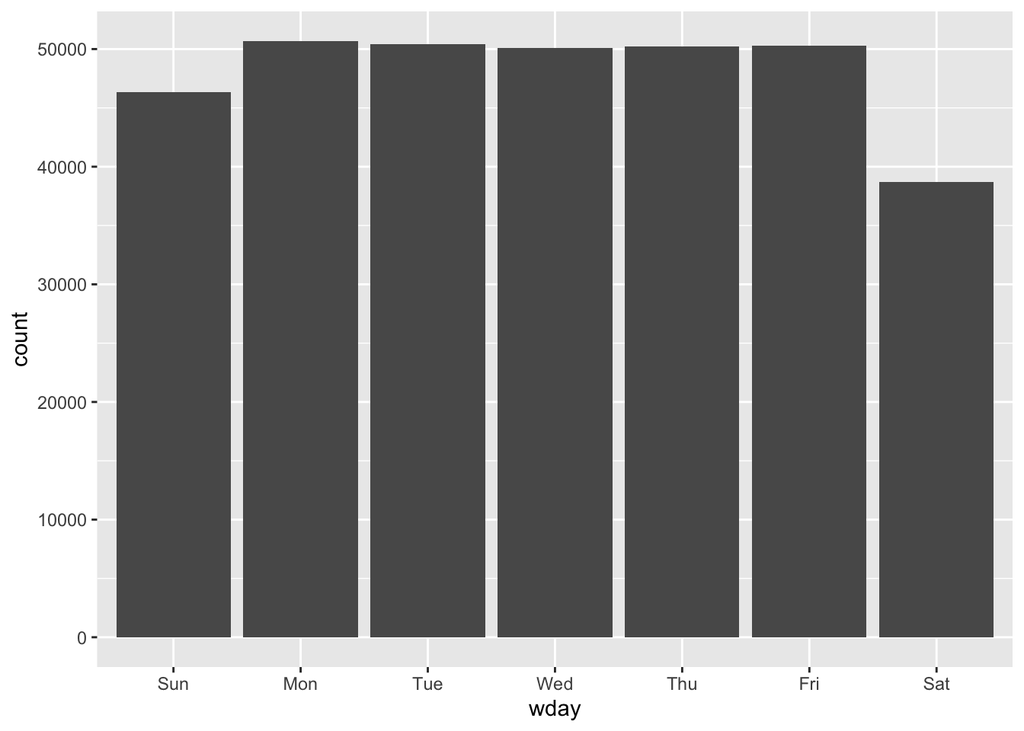

```r
flights_dt %>%
  filter(!is.na(dep.time)) %>%
  mutate(wday = wday(dep.time, label = TRUE, abb=TRUE)) %>%
  ggplot(aes(x = wday))+
  geom_bar()
```

Use the variable `dep.time` to create a barplot of the distribution of flights by month. Which month(s) seems to be the most busy in terms of number of flights departing NYC?

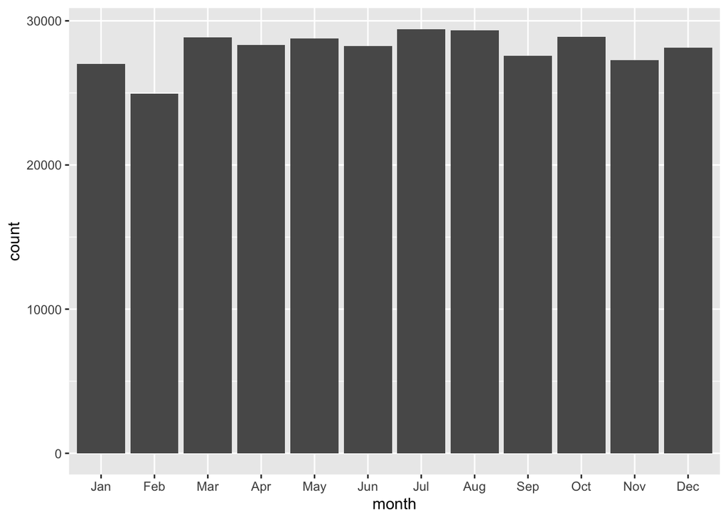

```r
flights_dt %>%
  filter(!is.na(dep.time)) %>%
  mutate(month = month(dep.time, label = TRUE, abbr=TRUE)) %>%
  ggplot(aes(x = month))+
  geom_bar()
```

Use the variable `dep.time` to create a barplot of the distribution of flights by day of month. Other than the 30th and the 31st, which day seems to be the least busy in terms of number of flights departing NYC?

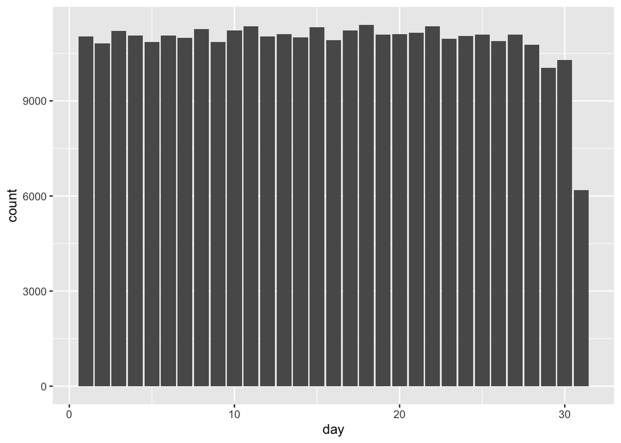

```r
flights_dt %>%
  filter(!is.na(dep.time)) %>%
  mutate(day = day(dep.time)) %>%
  ggplot(aes(x = day))+
  geom_bar()
```

Use the variable `dep.time` to create a barplot of the distribution of flights by hour of day. When do the NYC airports start departures daily?

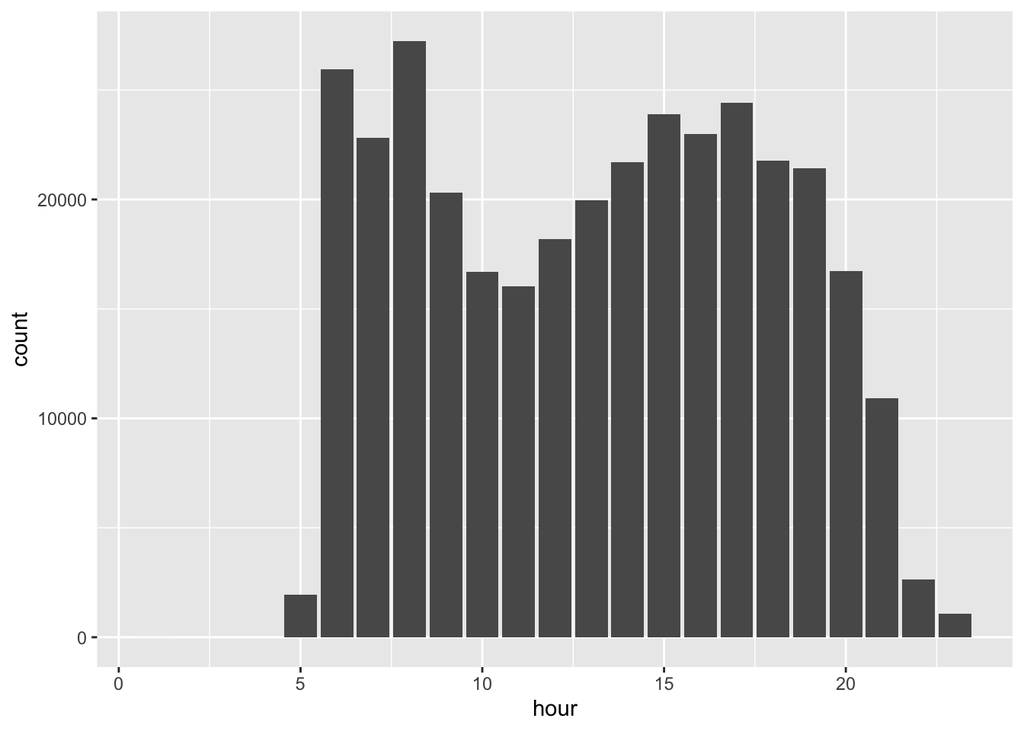

```r
flights_dt %>%
  filter(!is.na(dep.time)) %>%
  mutate(hour = hour(dep.time)) %>%
  ggplot(aes(x = hour))+
  geom_bar()
```

Use the variable `dep.time` to create a frequency polygon displaying the distribution of NYC flights’ departures by date and time.

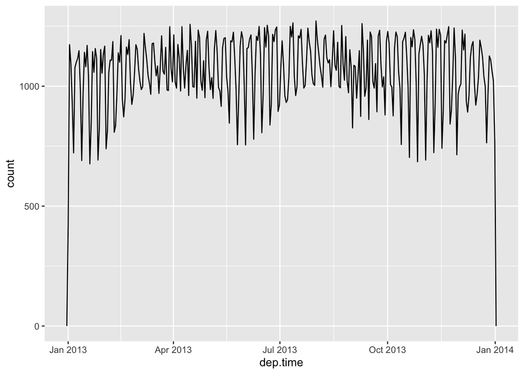

```r
flights_dt %>%
  filter(!is.na(dep.time)) %>%
  ggplot(aes(x = dep.time))+
  geom_freqpoly(binwidth=100000)
```

Using the function `seconds_to_period` we can switch air_time from minutes to hours_minutes_seconds. On the other side, the **more common** function `period_to_seconds` can be used to switch air_time from hours_minutes_seconds to seconds or minutes.

```r
flights %>%
  filter(!is.na(air_time)) %>%
  mutate(air.time = seconds_to_period(minutes(air_time))) %>%
  select(air_time, air.time) %>%
  mutate(air.time.new=period_to_seconds(air.time)) %>%
  head()
```

```
## # A tibble: 6 x 3
##   air_time air.time  air.time.new
##      <dbl> <Period>         <dbl>
## 1      227 3H 47M 0S        13620
## 2      227 3H 47M 0S        13620
## 3      160 2H 40M 0S         9600
## 4      183 3H 3M 0S         10980
## 5      116 1H 56M 0S         6960
## 6      150 2H 30M 0S         9000
```